# Compare baRulho and SIGPRO measurements

- Show All Code
- Hide All Code
- View Source

baRulho:quantifying habitat-induced degradation of (animal) acoustic signals

Author

Marcelo Araya-Salas

Published

October 8, 2024

# 1 Purpose

- Explore SIGPRO output
- Compare measurements between SIGPRO and baRulho

# 2 Report overview

- Compare SIGPRO and baRulho
  - Takeaways

# 3 Explore SIGPRO data

- Clips: measurements on cuts right at the start of the re-recorded sounds. **More precise**.
- Full recordings: measurements taken on the original re-recored files, so start of sounds was foud manually. **Less precise**. This is the default method when using SIGPRO.

```r
# sigpro_data <-
# as.data.frame(read_excel('./data/raw/sigpro_measurements_V02.xlsx'))
sigpro_data <- as.data.frame(read_excel("./data/raw/sigpro_measurements.xlsx"))

sigpro_data$SNR <- as.numeric(sigpro_data$SNR)
sigpro_data$TSR <- as.numeric(sigpro_data$TSR)

# exclude measurements on the first round for clips (did not
# include TSR)
sigpro_data <- sigpro_data[sigpro_data$format != "Clips 1st round",
    ]

names(sigpro_data)[names(sigpro_data) %in% c("Blur ratio (E-blur)",
    "E-Match k")] <- c("blur_ratio", "k")

# fix outliers
sigpro_data$blur_ratio[sigpro_data$blur_ratio > 20] <- NA

sigpro_data$k[sigpro_data$k > 20] <- NA

# fix labels
sigpro_data$format <- ifelse(sigpro_data$format == "Completo", "Full recording",
    "Clips")


# excess attenuation no extra dB adding chirras
sigpro_data$excess_attenuation <- (-20 * log(sigpro_data$k)) - (6/(2 *
    (sigpro_data$distance - 1)))

# Darden sigpro_data$excess_attenuation <- (-20 *
# log(sigpro_data$k)) - (20 * log(sigpro_data$distance / 10))


# Maad att_geo_fac <- 1 / 20 -20*log10(att_geo_fac)
# sigpro_data$excess_attenuation.maad <- (-20 *
# log10(sigpro_data$k)) - (20 * log10(1 / sigpro_data$distance))
# sigpro_data$excess_attenuation.luis <- (-20 *
# log(sigpro_data$k)) - (6 / (2 * (sigpro_data$distance - 1)))

sigpro_data$excess_attenuation[is.infinite(sigpro_data$excess_attenuation) |
    is.nan(sigpro_data$excess_attenuation)] <- NA
# sigpro_data$excess_attenuation.luis[is.infinite(sigpro_data$excess_attenuation.luis)]
# <- NA

degrad_params <- c("SNR", "TSR", "blur_ratio", "k", "excess_attenuation")
```

# 4 Compare SIGPRO and baRulho

Re-measuring transmission parameters:

Dotted lines show x = y

```r
comb_data_cols <- read.csv("./data/processed/combined_sigpro_barulho.csv")

for (i in c("TSR", "SNR", "blur_ratio", "excess_attenuation")) {

    cat("<br>")
    cat(i)
    cat("<br>")
    # print(paste('Pearson correlation clips:',
    # round(cor(comb_data_cols[comb_data_cols$format == 'Clips',
    # i], comb_data_cols[comb_data_cols$format == 'Clips',
    # paste(i, 'bRlho', sep = '-')], use =
    # 'pairwise.complete.obs'), 2)))

    # clips
    x <- comb_data_cols[comb_data_cols$format == "Clips", i]
    y <- comb_data_cols[comb_data_cols$format == "Clips", paste(i,
        "bRlho", sep = ".")]

    cr.clps <- cor.test(x, y, use = "pairwise.complete.obs")
    p <- round(cr.clps$p.value, 3)
    if (p < 0.001)
        p <- "p < 0.001"
    print(paste("Pearson correlation clips: r=", round(cr.clps$estimate,
        2), "; p =", p))

    cat("<br>")

    # complete recordings
    x <- comb_data_cols[comb_data_cols$format == "Full recording",
        i]
    y <- comb_data_cols[comb_data_cols$format == "Full recording",
        paste(i, "bRlho", sep = ".")]

    cr.fr <- cor.test(x, y, use = "pairwise.complete.obs")
    p <- round(cr.fr$p.value, 3)
    if (p < 0.001)
        p <- "p < 0.001"
    print(paste("Pearson correlation full recordings: r=", round(cr.fr$estimate,
        2), "; p =", p))

    xy_ranges <- range(c(comb_data_cols[, i], comb_data_cols[, paste(i,
        "bRlho", sep = ".")]), na.rm = TRUE)

    plt <- ggplot(comb_data_cols, aes(x = get(i), y = get(paste(i,
        "bRlho", sep = ".")))) + geom_point(color = viridis(10, alpha = 0.7)[7]) +
        xlim(xy_ranges) + ylim(xy_ranges) + labs(x = paste(i, "SIGPRO"),
        y = paste(i, "baRulho")) + facet_wrap(~format, scales = "free_x") +
        geom_abline(slope = 1, intercept = 0, lty = 3) + theme_classic()

    cat("<br>")

    print(plt)
}
```

TSR  
[1] “Pearson correlation clips: r= 0.8 ; p = p < 0.001”  
[1] “Pearson correlation full recordings: r= 0.61 ; p = p < 0.001”

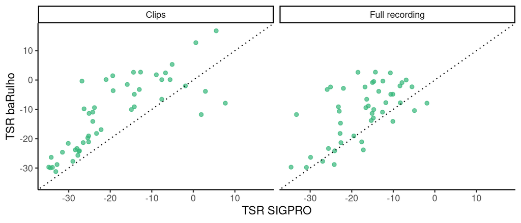

SNR  
[1] “Pearson correlation clips: r= 0.94 ; p = p < 0.001”  
[1] “Pearson correlation full recordings: r= 0.79 ; p = p < 0.001”

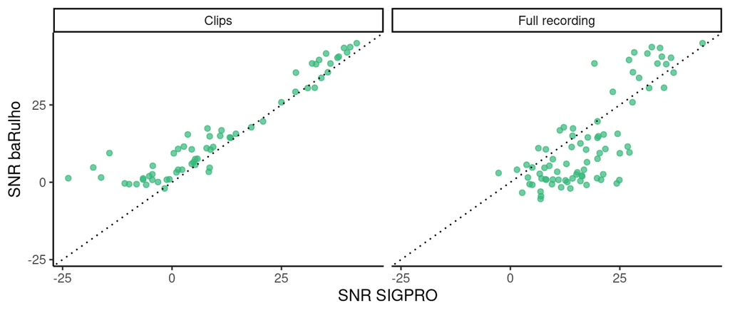

blur_ratio  
[1] “Pearson correlation clips: r= 0.8 ; p = p < 0.001”  
[1] “Pearson correlation full recordings: r= 0.5 ; p = p < 0.001”

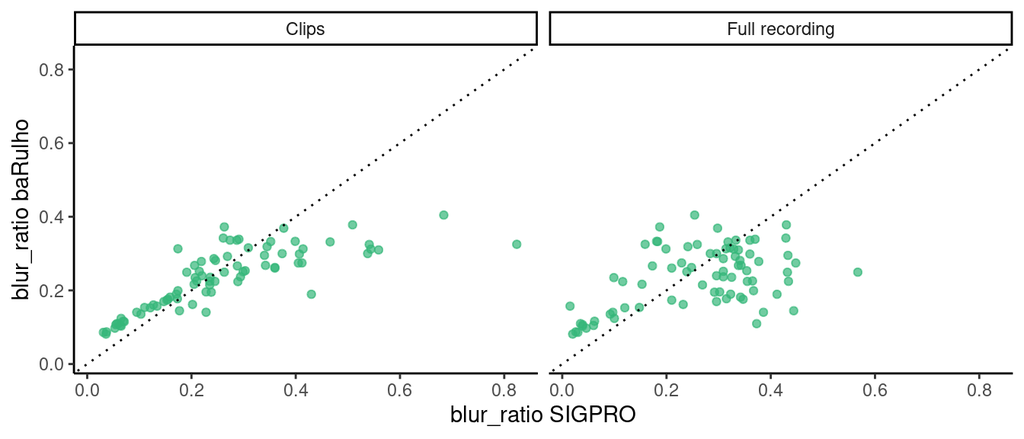

excess_attenuation  
[1] “Pearson correlation clips: r= 0.97 ; p = p < 0.001”  
[1] “Pearson correlation full recordings: r= 0.75 ; p = p < 0.001”

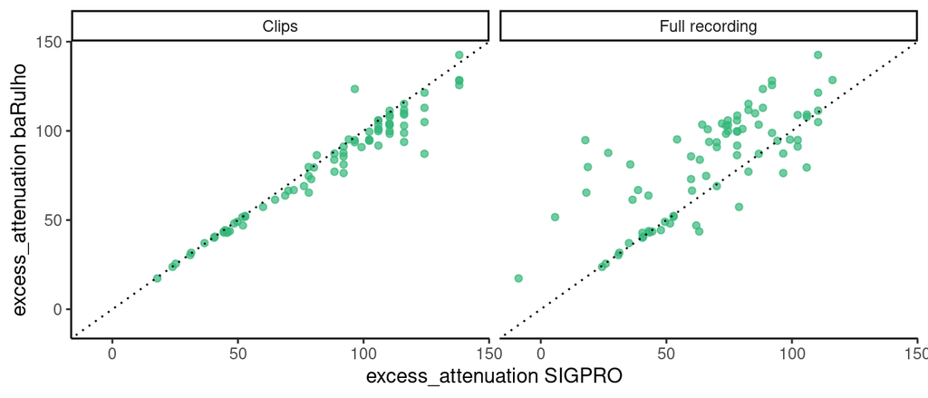

Removing 100 m test data

```r
comb_data_cols <- read.csv("./data/processed/combined_sigpro_barulho.csv")
comb_data_cols <- comb_data_cols[comb_data_cols$distance != 100, ]
for (i in c("TSR", "SNR", "blur_ratio", "excess_attenuation")) {

    cat("<br>")
    cat(i)
    cat("<br>")
    # print(paste('Pearson correlation clips:',
    # round(cor(comb_data_cols[comb_data_cols$format == 'Clips',
    # i], comb_data_cols[comb_data_cols$format == 'Clips',
    # paste(i, 'bRlho', sep = '-')], use =
    # 'pairwise.complete.obs'), 2)))

    # clips
    x <- comb_data_cols[comb_data_cols$format == "Clips", i]
    y <- comb_data_cols[comb_data_cols$format == "Clips", paste(i,
        "bRlho", sep = ".")]

    cr.clps <- cor.test(x, y, use = "pairwise.complete.obs")
    p <- round(cr.clps$p.value, 3)
    if (p < 0.001)
        p <- "p < 0.001"
    print(paste("Pearson correlation clips: r=", round(cr.clps$estimate,
        2), "; p =", p))

    cat("<br>")

    # complete recordings
    x <- comb_data_cols[comb_data_cols$format == "Full recording",
        i]
    y <- comb_data_cols[comb_data_cols$format == "Full recording",
        paste(i, "bRlho", sep = ".")]

    cr.fr <- cor.test(x, y, use = "pairwise.complete.obs")
    p <- round(cr.fr$p.value, 3)
    if (p < 0.001)
        p <- "p < 0.001"
    print(paste("Pearson correlation full recordings: r=", round(cr.fr$estimate,
        2), "; p =", p))

    xy_ranges <- range(c(comb_data_cols[, i], comb_data_cols[, paste(i,
        "bRlho", sep = ".")]), na.rm = TRUE)

    plt <- ggplot(comb_data_cols, aes(x = get(i), y = get(paste(i,
        "bRlho", sep = ".")))) + geom_point(color = viridis(10, alpha = 0.7)[7]) +
        xlim(xy_ranges) + ylim(xy_ranges) + labs(x = paste(i, "SIGPRO"),
        y = paste(i, "baRulho")) + facet_wrap(~format, scales = "free_x") +
        geom_abline(slope = 1, intercept = 0, lty = 3) + theme_classic()

    cat("<br>")

    print(plt)
}
```

TSR  
[1] “Pearson correlation clips: r= 0.81 ; p = p < 0.001”  
[1] “Pearson correlation full recordings: r= 0.59 ; p = p < 0.001”

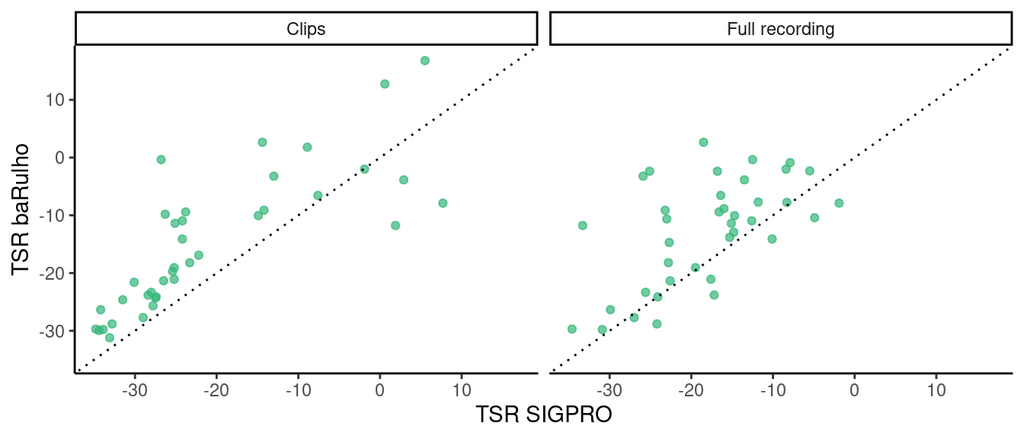

SNR  
[1] “Pearson correlation clips: r= 0.95 ; p = p < 0.001”  
[1] “Pearson correlation full recordings: r= 0.85 ; p = p < 0.001”

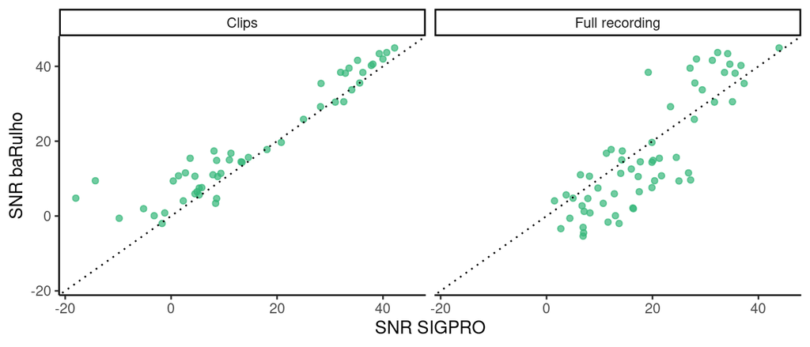

blur_ratio  
[1] “Pearson correlation clips: r= 0.84 ; p = p < 0.001”  
[1] “Pearson correlation full recordings: r= 0.42 ; p = 0.001”

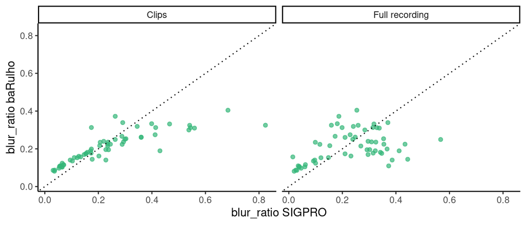

excess_attenuation  
[1] “Pearson correlation clips: r= 0.98 ; p = p < 0.001”  
[1] “Pearson correlation full recordings: r= 0.74 ; p = p < 0.001”

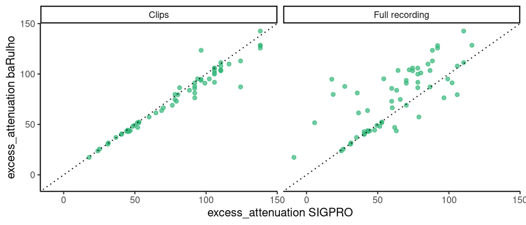

# 5 Takeaways